# Repeated Measures aov

## This is what the data look like in terms of percent differences from midshaft:

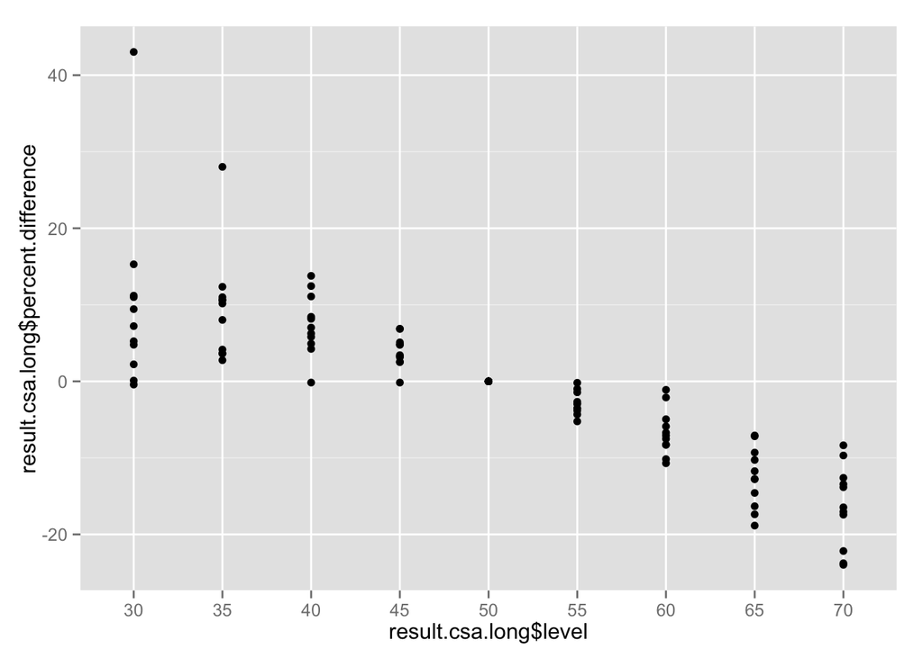

#### And we want to know, at what point do these differences become significantly different?

Previous papers have used paired t-tests to assess this. These are the Bonferroni Corrected p-values from paired t-tests.

```r
csa.ttest
```

```
##   level   p-value
## 1    30 0.3217856
## 2    35 0.0326606
## 3    40 0.0013231
## 4    45 0.0014060
## 5    55 0.0010267
## 6    60 0.0016616
## 7    65 0.0002249
## 8    70 0.0003340
```

##### It seems that this method might be a little too aggressive in finding significant differences when none may actually exist

## *Background Code*

```r
midshaft.raw.csa.function <- function(x)
{
  slicelength <- as.numeric(length(csa[which(label == x)]))
  slice.intervals <- as.integer(seq(1,slicelength, by=(slicelength*.05)))
  slice.intervals <- slice.intervals + min(slice[which(label == x)])
  slice.bind <- cbind(seq(1, slicelength), (csa[which(label == x)]))
  slice.matrix <- as.matrix(slice.bind[slice.intervals, ])
  csa.levels <- data.frame(rbind(slice.matrix[,2]))
  csa.levels <- cbind(x, csa.levels)
  colnames(csa.levels) <- c("specimen", seq(0,95, by=5))
  return(csa.levels)
}


raw.csa.result = mdply(unique(x), midshaft.raw.csa.function)
raw.result.csa.long <- melt(raw.csa.result, variable.name="level", value.name="raw.value")

raw.result.csa.long <- rbind(raw.result.csa.long[which(raw.result.csa.long$level == 30),],
                             raw.result.csa.long[which(raw.result.csa.long$level == 35),],
                             raw.result.csa.long[which(raw.result.csa.long$level == 40),],
                             raw.result.csa.long[which(raw.result.csa.long$level == 45),],
                             raw.result.csa.long[which(raw.result.csa.long$level == 50),],
                             raw.result.csa.long[which(raw.result.csa.long$level == 55),],
                             raw.result.csa.long[which(raw.result.csa.long$level == 60),],
                             raw.result.csa.long[which(raw.result.csa.long$level == 65),],
                             raw.result.csa.long[which(raw.result.csa.long$level == 70),])
```

## Standard Repeated Measures Anova

trying to account for repeated measures (levels) from the same specimens

```r
m <- aov(raw.result.csa.long$raw.value ~ raw.result.csa.long$level + Error(raw.result.csa.long$specimen/raw.result.csa.long$level))
summary(m)
```

```
##
## Error: raw.result.csa.long$specimen
##           Df Sum Sq Mean Sq F value Pr(>F)
## Residuals 10 504870   50487
##
## Error: raw.result.csa.long$specimen:raw.result.csa.long$level
##                           Df Sum Sq Mean Sq F value Pr(>F)
## raw.result.csa.long$level  8 124846   15606    24.1 <2e-16 ***
## Residuals                 80  51740     647
## ---
## Signif. codes:  0 '***' 0.001 '**' 0.01 '*' 0.05 '.' 0.1 ' ' 1
```

Setting up the error structure this way yields the same results:

```r
m <- aov(raw.result.csa.long$raw.value ~ raw.result.csa.long$level + Error(raw.result.csa.long$specimen))
summary(m)
```

```
##
## Error: raw.result.csa.long$specimen
##           Df Sum Sq Mean Sq F value Pr(>F)
## Residuals 10 504870   50487
##
## Error: Within
##                           Df Sum Sq Mean Sq F value Pr(>F)
## raw.result.csa.long$level  8 124846   15606    24.1 <2e-16 ***
## Residuals                 80  51740     647
## ---
## Signif. codes:  0 '***' 0.001 '**' 0.01 '*' 0.05 '.' 0.1 ' ' 1
```

The previous methods (assuming error structure was correct) don’t work with TukeyHSD test. Either need different test or different type of object output. The following code was suggested to fix that

```r
m <- aov(terms(raw.result.csa.long$raw.value ~ raw.result.csa.long$level + (raw.result.csa.long$specimen)))
summary(m)
```

```
##                              Df Sum Sq Mean Sq F value Pr(>F)
## raw.result.csa.long$level     8 124846   15606    24.1 <2e-16 ***
## raw.result.csa.long$specimen 10 504870   50487    78.1 <2e-16 ***
## Residuals                    80  51740     647
## ---
## Signif. codes:  0 '***' 0.001 '**' 0.01 '*' 0.05 '.' 0.1 ' ' 1
```

```r
head(TukeyHSD(m))
```

```
## $`raw.result.csa.long$level`
##           diff     lwr     upr     p adj
## 35-30   -2.611  -37.18  31.962 1.000e+00
## 40-30  -11.706  -46.28  22.867 9.756e-01
## 45-30  -24.783  -59.36   9.790 3.632e-01
## 50-30  -39.766  -74.34  -5.192 1.244e-02
## 55-30  -51.132  -85.71 -16.559 3.321e-04
## 60-30  -65.998 -100.57 -31.424 1.330e-06
## 65-30  -89.894 -124.47 -55.321 6.823e-11
## 70-30 -104.277 -138.85 -69.703 0.000e+00
## 40-35   -9.095  -43.67  25.478 9.953e-01
## 45-35  -22.172  -56.75  12.401 5.178e-01
## 50-35  -37.155  -71.73  -2.581 2.566e-02
## 55-35  -48.521  -83.09 -13.948 8.085e-04
## 60-35  -63.387  -97.96 -28.813 3.668e-06
## 65-35  -87.283 -121.86 -52.710 2.222e-10
## 70-35 -101.665 -136.24 -67.092 0.000e+00
## 45-40  -13.077  -47.65  21.497 9.529e-01
## 50-40  -28.059  -62.63   6.514 2.084e-01
## 55-40  -39.426  -74.00  -4.852 1.370e-02
## 60-40  -54.291  -88.86 -19.718 1.090e-04
## 65-40  -78.188 -112.76 -43.614 9.945e-09
## 70-40  -92.570 -127.14 -57.997 1.557e-11
## 50-45  -14.982  -49.56  19.591 9.015e-01
## 55-45  -26.349  -60.92   8.225 2.827e-01
## 60-45  -41.215  -75.79  -6.641 8.156e-03
## 65-45  -65.111  -99.68 -30.538 1.881e-06
## 70-45  -79.493 -114.07 -44.920 5.817e-09
## 55-50  -11.367  -45.94  23.207 9.796e-01
## 60-50  -26.232  -60.81   8.341 2.883e-01
## 65-50  -50.129  -84.70 -15.555 4.692e-04
## 70-50  -64.511  -99.08 -29.937 2.375e-06
## 60-55  -14.866  -49.44  19.708 9.054e-01
## 65-55  -38.762  -73.34  -4.189 1.652e-02
## 70-55  -53.144  -87.72 -18.571 1.641e-04
## 65-60  -23.897  -58.47  10.677 4.134e-01
## 70-60  -38.279  -72.85  -3.705 1.890e-02
## 70-65  -14.382  -48.96  20.191 9.204e-01
##
## $`raw.result.csa.long$specimen`
```

[output cut: 41 more lines]

```
## SBUhuman_7_femur-SBUhuman_6_femur      8.335  -31.3908   48.0599 9.998e-01
## SBUhuman_8_femur-SBUhuman_6_femur   -220.983 -260.7087 -181.2580 0.000e+00
## SBUhuman_9_femur-SBUhuman_6_femur   -131.157 -170.8822  -91.4316 0.000e+00
## SBUhuman_10_femur-SBUhuman_6_femur   -56.183  -95.9087  -16.4580 5.530e-04
## SBUhuman_43_femur-SBUhuman_6_femur  -141.655 -181.3800 -101.9293 0.000e+00
## SBUhuman_8_femur-SBUhuman_7_femur   -229.318 -269.0432 -189.5926 0.000e+00
## SBUhuman_9_femur-SBUhuman_7_femur   -139.491 -179.2168  -99.7661 0.000e+00
## SBUhuman_10_femur-SBUhuman_7_femur   -64.518 -104.2432  -24.7926 3.724e-05
## SBUhuman_43_femur-SBUhuman_7_femur  -149.989 -189.7145 -110.2639 0.000e+00
## SBUhuman_9_femur-SBUhuman_8_femur     89.826   50.1011  129.5518 4.300e-09
## SBUhuman_10_femur-SBUhuman_8_femur   164.800  125.0747  204.5253 0.000e+00
## SBUhuman_43_femur-SBUhuman_8_femur    79.329   39.6033  119.0540 2.062e-07
## SBUhuman_10_femur-SBUhuman_9_femur    74.974   35.2482  114.6989 9.893e-07
## SBUhuman_43_femur-SBUhuman_9_femur   -10.498  -50.2231   29.2275 9.984e-01
## SBUhuman_43_femur-SBUhuman_10_femur  -85.471 -125.1967  -45.7460 2.170e-08
```

but gives way too many comparisons…

using level as error term seems to give the correct tukey comparisons, but is probably not the right repeated measures term…

```r
m <- aov(terms(raw.result.csa.long$raw.value ~ raw.result.csa.long$level + (raw.result.csa.long$level)))
head(TukeyHSD(m))
```

```
## $`raw.result.csa.long$level`
##           diff    lwr     upr   p adj
## 35-30   -2.611 -109.2 103.976 1.00000
## 40-30  -11.706 -118.3  94.881 0.99999
## 45-30  -24.783 -131.4  81.804 0.99805
## 50-30  -39.766 -146.4  66.821 0.95753
## 55-30  -51.132 -157.7  55.455 0.84092
## 60-30  -65.998 -172.6  40.589 0.56920
## 65-30  -89.894 -196.5  16.693 0.16967
## 70-30 -104.277 -210.9   2.310 0.06017
## 40-35   -9.095 -115.7  97.492 1.00000
## 45-35  -22.172 -128.8  84.415 0.99912
## 50-35  -37.155 -143.7  69.432 0.97160
## 55-35  -48.521 -155.1  58.066 0.87618
## 60-35  -63.387 -170.0  43.200 0.62209
## 65-35  -87.283 -193.9  19.304 0.20014
## 70-35 -101.665 -208.3   4.921 0.07373
## 45-40  -13.077 -119.7  93.510 0.99998
## 50-40  -28.059 -134.6  78.528 0.99538
## 55-40  -39.426 -146.0  67.161 0.95959
## 60-40  -54.291 -160.9  52.295 0.79191
## 65-40  -78.188 -184.8  28.399 0.33482
## 70-40  -92.570 -199.2  14.017 0.14215
## 50-45  -14.982 -121.6  91.604 0.99995
## 55-45  -26.349 -132.9  80.238 0.99701
## 60-45  -41.215 -147.8  65.372 0.94786
## 65-45  -65.111 -171.7  41.476 0.58722
## 70-45  -79.493 -186.1  27.094 0.31286
## 55-50  -11.367 -118.0  95.220 0.99999
## 60-50  -26.232 -132.8  80.355 0.99710
## 65-50  -50.129 -156.7  56.458 0.85506
## 70-50  -64.511 -171.1  42.076 0.59939
## 60-55  -14.866 -121.5  91.721 0.99996
## 65-55  -38.762 -145.3  67.825 0.96342
## 70-55  -53.144 -159.7  53.443 0.81047
## 65-60  -23.897 -130.5  82.690 0.99850
## 70-60  -38.279 -144.9  68.308 0.96604
## 70-65  -14.382 -121.0  92.205 0.99997
```

##### Is a repeated measures ANOVA the best approach?

- If so, is the error structure correct?
- and is the post hoc test the most appropriate choice?